# Exploratory Analysis of US Election Survey Data ANES

## Introduction

In this notebook, we are interested in the education distribution per party. In other words, we look to answer: are more educated people more liberal or conservative?

In my experience in undergraduate and post-graduate, most people are liberal. Thus my intuition is there will be a correlation between higher education degree and more liberal political view.

## Correlation of education and party identification

Import processed data. We take a look at the education distribution of the voters versus political identification.

For instance, in 2016, how many legit answers are there in total?

```
##   No. Response 2016 Democrat Republican
## 1              4211     1924       1719
```

```
##            Grade School High School Some Colleges College or higher
## Democrat      1.3513514     23.7526      32.74428          42.15177
## Republican    0.6980803     22.2804      37.28912          39.73240
```

It seems like so far in 2016, people who have college degrees and higher tend to identify themselves as democrat, though the ratio is not much higher.

Let us look at the data accross the years. This is slightly longer, thus relegated to `edu.R`

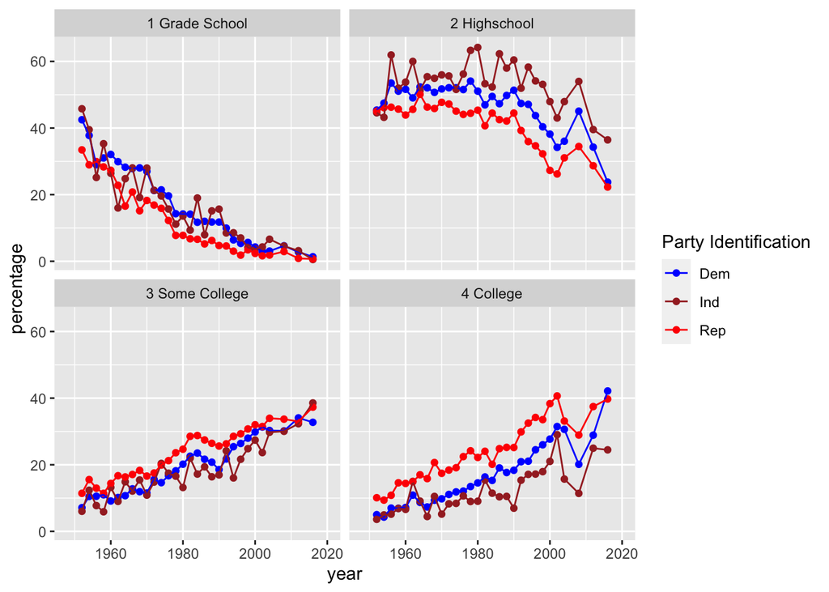

Looking at the previous years tell a different story. It seems that across the years, a Democrat will likely in the first two categories (`Grade school` and `High School`), while a Republican will more likely in the other two (`Some colleges` and `College or higher`). To render our analysis more quantitative, let us look at the average across the years

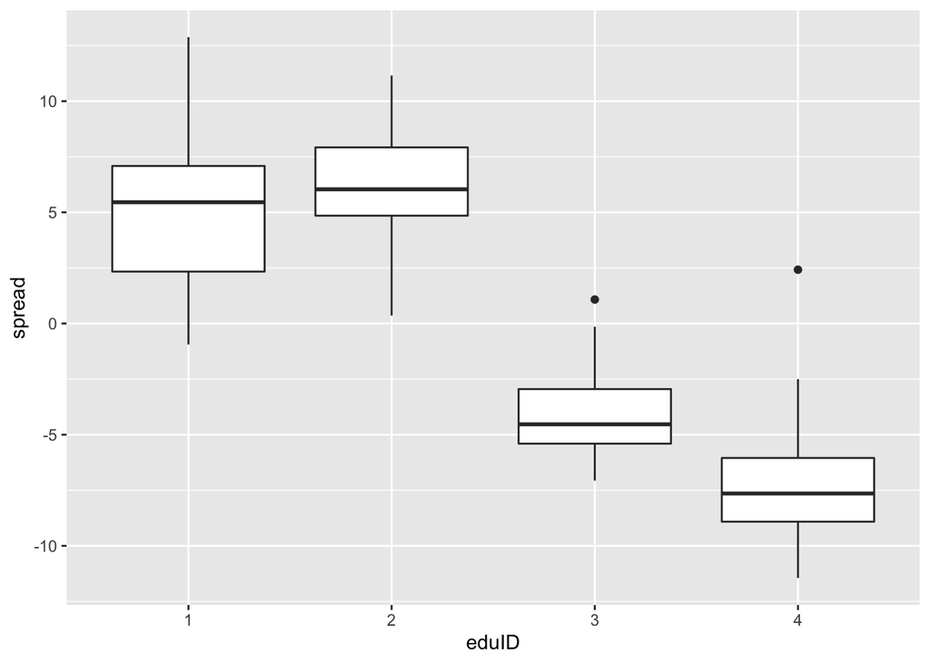

This boxplot indicates two things: * Less educated respondents tend to identify as democrats. More educated respondents tend to identify as republicans. * 2016 is a outlier for the `college and higher` category, while 2012 is a outlier for the `some colleges` category.

## Correllation to `temperature` data

Temperature data measure respondents’ feeling toward a certain keyword. Let us take a look at a few significant keywords. First, let see how each group feels toward `Democratic Party`.

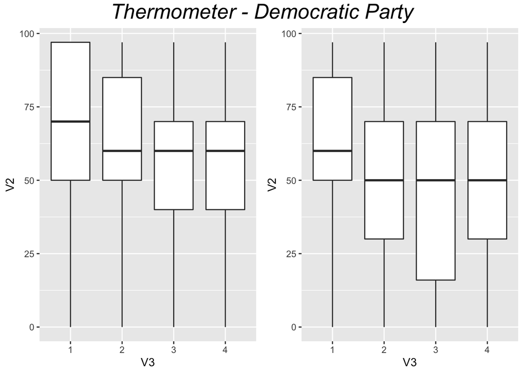

It seems that the feeling toward the Democrat Party is not as hot in 2016, but the change uniform across the board. What about the `Republican Party` ?

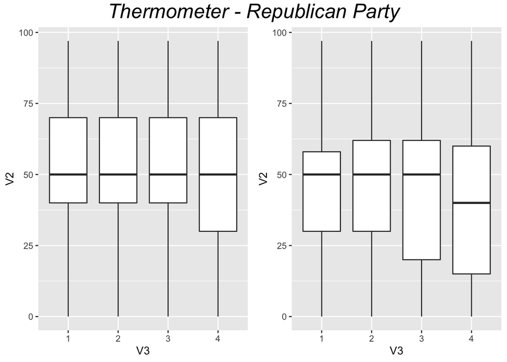

This still does not explain why the Republican appeal better to the fourth group in general, while the Democrat party appeal to the less educated group. Taking a look at a few other keywords may reveal the reasons.